# Code for reproducing the narwhal case study

Inferring resource selection and utilization distributions from irregular and error-prone animal tracking data using the habitat-driven Langevin diffusion

Fanny Dupont, Brett T. McClintock, Jan-Ole Fischer, Nigel E. Hussey, Marianne Marcoux, Marie Auger-Méthé

This document presents annotated code and explanations for the case study, together with the steps used to obtain the results. The two-step method relies on the `fitLangevin()` function from the `langevinSSM` package, whereas the SSM–Langevin approach is implemented using custom code built with TMB and C++. All required code and documents are included in the folder.

Set the seed to get the same results

```r
set.seed(1,kind="Mersenne-Twister",normal.kind = "Inversion")
```

# 1. Prepare the data

Load the environmental covariates. They must have the same dimensions: the same number of cells and the same raster size. The bathymetry raster comes from the International Bathymetric Chart of the Arctic Ocean (https://www.gebco.net/data-products-gridded-bathymetry-data/gebco2024-grid)

The mask raster takes the value 1 for land and 0 otherwise.

The covariates that will be used as covariate in the analysis

- Bathymetry (`bathy_scaled`) from the International Bathymetric Chart of the Arctic Ocean (https://www.gebco.net/data-products-gridded-bathymetry-data/gebco2024-grid)
- Landmask (`landmask_scaled`): derived from the binary mask covariate (1 = land, 0 = water). It represents the distance to the nearest water cell, with values close to $0$ on water and increasing with distance from water. This covariate is used to impose the land constraint.

All covariate rasters are scaled such that their gradients range between 0 and 0.1, improving model stability and performance in TMB. Similarly, all location coordinates are converted to km by dividing by 1e3. I use a penalty to enforce data on water (works well in the work with Brett)

```r
setwd("/Users/fannydupont/Desktop/PhD/LangevinSSM_Revision/Github/Code_Case_Study")
```

Scale all rasters from meters to kilometers. This improves numerical stability in TMB, which is not very stable with very large covariate values.

```r
landmask2 = mask # 1 if on land, NA otherwise. Is used for the constraint
landmask2[landmask2==1] = NA
dist_to_w = raster::distance(landmask2)

landmask = dist_to_w
```

```r
bathy <- min(bathy, 0)

# convert raster to data frame
df_bathy <- as.data.frame(bathy, xy = TRUE, na.rm = FALSE)
names(df_bathy)[3] <- "depth"

pdf("plots_bathy.pdf", width = 35, height = 40)
ggplot(df_bathy, aes(x = x, y = y, fill = depth)) +
  geom_raster() +
  scale_fill_gradientn(
    colours  = colorRampPalette(c("#08306b", "#2171b5", "#6baed6", "#c6dbef", "white"))(100),
    na.value = "white"
  ) +
  guides(fill = guide_colorbar(
    barwidth        = unit(2,  "cm"),
    barheight       = unit(20, "cm"),
    ticks.linewidth = 3,
    ticks.colour    = "black",
    frame.colour    = "black",
    frame.linewidth = 1.5
  )) +
  labs(title = "", x = "", y = "", fill = "Depth") +
  theme_bw() +
  theme(panel.grid       = element_blank(),
        plot.title       = element_text(hjust = 1, size = 45),
        legend.text      = element_text(size = 55),
        legend.title      = element_text(size = 55, margin = margin(b = 20)),
        axis.text        = element_text(size = 55),
        axis.title       = element_text(size = 55),
        axis.ticks       = element_line(linewidth = 1.5),
        axis.ticks.length = unit(0.4, "cm"))
dev.off()
```

Plot the scaled covariates, whose gradient L2 norms have been rescaled between $0$ and $0.1$ to improve numerical stability in the model.

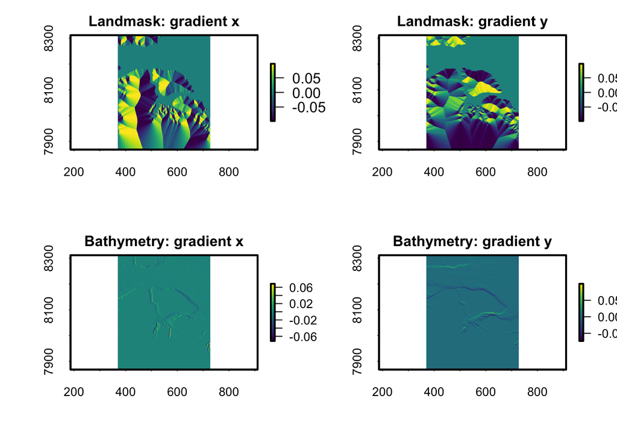

```r
par(mfrow = c(2, 2))  # 2 rows, 2 columns

par(
  xpd = FALSE,
  cex = 1,
  cex.axis = 1,
  cex.lab  = 1,
  lwd = 2,
  mar = c(4, 4, 2, 2),  # slightly tighter margins for 4 plots
  xaxs = "i",
  yaxs = "i"
)

# Compute gradients once
grad_land <- ctmcmove::rast.grad(landmask_scaled)
grad_bathy <- ctmcmove::rast.grad(bathy_scaled)

# ---- Landmask: gradient x direction
plot(grad_land$rast.grad.x,
     col = viridis::viridis(100),
     main = "", xlab = "", ylab = "",
     legend = TRUE, axes = FALSE)
axis(1, tck = -0.01)
axis(2, tck = -0.01)
box()
title(main = "Landmask: gradient x")

# ---- Landmask: gradient y direction
plot(grad_land$rast.grad.y,
     col = viridis::viridis(100),
     main = "", xlab = "", ylab = "",
     legend = TRUE, axes = FALSE)
axis(1, tck = -0.01)
axis(2, tck = -0.01)
box()
title(main = "Landmask: gradient y")

# ---- Bathymetry: gradient x direction ----
plot(grad_bathy$rast.grad.x,
     col = viridis::viridis(100),
     main = "", xlab = "", ylab = "",
     legend = TRUE, axes = FALSE)
axis(1, tck = -0.01)
axis(2, tck = -0.01)
box()
title(main = "Bathymetry: gradient x")

# ---- Bathymetry: gradient y direction ----
plot(grad_bathy$rast.grad.y,
     col = viridis::viridis(100),
     main = "", xlab = "", ylab = "",
     legend = TRUE, axes = FALSE)
axis(1, tck = -0.01)
axis(2, tck = -0.01)
box()
title(main = "Bathymetry: gradient y")
```

Next, we load the narwhal data and have a look at it.

The dataset was preprocessed before analysis. Tracks with gaps longer than two hours were split, and only segments containing more than fifteen locations were retained. Locations with class “Z” were removed, and ARGOS points with extremely large positional uncertainty (`smaj` $\geq$ 1e5) or with missing error estimates were excluded.

The resulting dataset includes the following columns:

- **ID** – animal identifier; for split tracks, the part after a dash indicates the segment.
- **type** – either `"Argos"` or `"FastGPS"`.
- **datetime_UTC** – date and time of the observation in Coordinated Universal Time (UTC).
- **loc_class** – ARGOS location class, or `"G"` for FastLoc GPS
- **smaj, smin, eor** – parameters of the ARGOS measurement error ellipse. For fastloc GPS, these were set to $50$ meters as recommended by Wildlife Computers (https://wildlifecomputers.com/data/technologies/fastloc/?utm_source=chatgpt.com). `"smin"` and `"smaj"` are in kilometers.
- **X, Y** – Narwhal locations in the bathymetry coordinate reference system, already divided by 1e3
- **lon, lat** - Narwhal locations in lon/lat format
- **velocity** – animal velocity in kilometers per hour, calculated as the straight-line distance between consecutive locations divided by the time elapsed. The distance was computed using the great-circle distance between successive points, and the time difference was calculated in hours. Velocity was then obtained by dividing the distance by the time interval.
- **dt** time difference, in hours, between consecutive locations

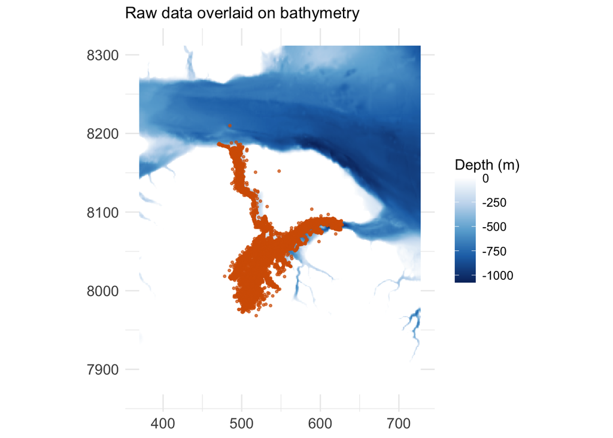

```r
# Convert data_ALL to sf (already done)
data_ALL.sf <- st_as_sf(data_ALL, coords = c("X", "Y"), remove = FALSE, crs = crs(bathy))

nbAnimals = length(unique(data_ALL.sf$ID))

# Convert bathy raster to data.frame for ggplot
bathy_df <- as.data.frame(bathy, xy = TRUE)
colnames(bathy_df) <- c("x", "y", "depth")

# Plot bathymetry + points
ggplot() +
  geom_raster(data = bathy_df, aes(x = x, y = y, fill = depth)) +
  geom_point(data = data_ALL.sf, aes(x = X, y = Y),
             color = "#D55E00", size =0.7, alpha = 0.7) +  # customize points as needed
  scale_fill_gradientn(colors = colorRampPalette(c("#08306b", "#2171b5", "#6baed6", "#c6dbef", "white"))(100),
                       name = "Depth (m)") +
  coord_equal() +
  theme_minimal() +
  theme(
    axis.title = element_blank(),
    axis.text = element_text(size = 12),
    legend.title = element_text(size = 12),
    legend.text = element_text(size = 10)
  )+
  ggtitle("Raw data overlaid on bathymetry")
```

This code can be executed to extract additional information about the locations of points relative to land, water, and other environmental covariates.

#### (b) Example: Save points whose associated ellipses have a 97.5% confidence area that does not extend over water

```r
ani_data <- data_ALL %>%
  dplyr::select(id = ID, date = datetime_UTC, lc = loc_class, lon,lat, smaj, smin, eor)
```

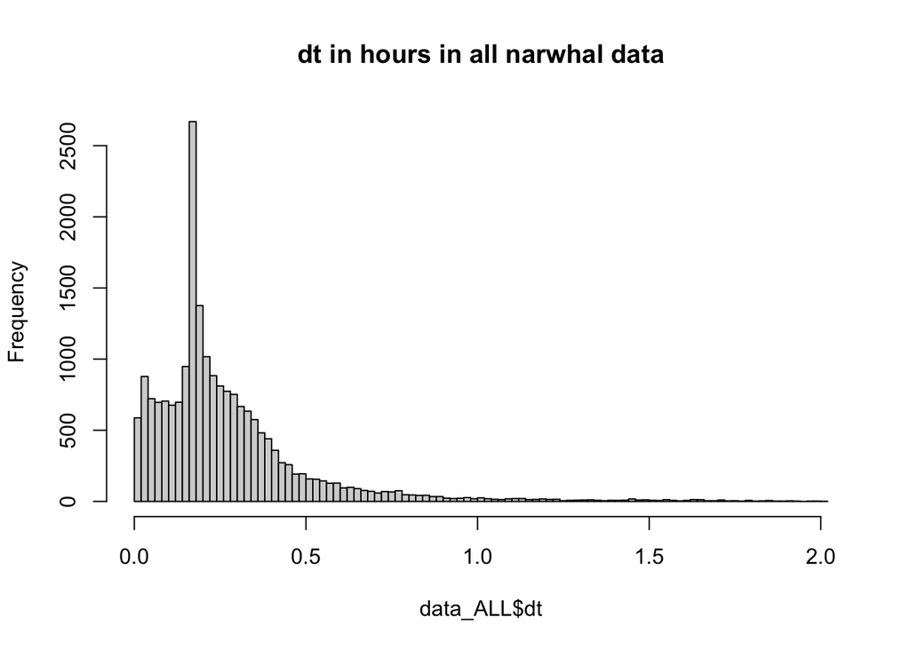

```r
hist(data_ALL$dt,breaks=100,main=c("dt in hours in all narwhal data"))
```

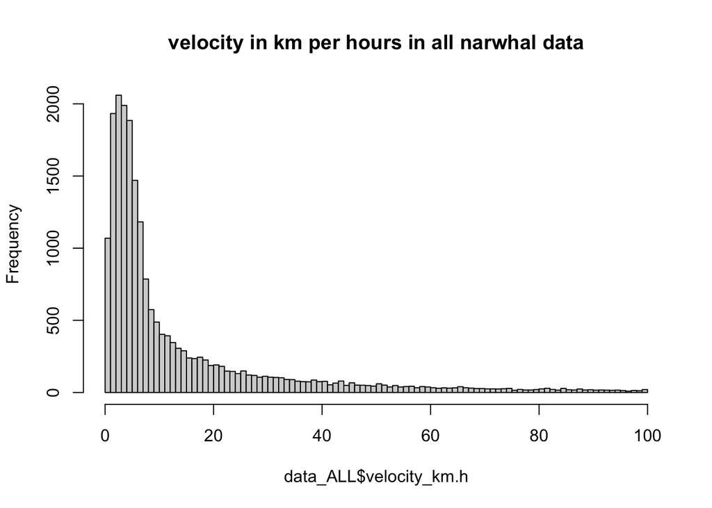

```r
hist(data_ALL$velocity_km.h,breaks=100,main=c("velocity in km per hours in all narwhal data"))
```

There are a few extremely high, unrealistic velocities in the data; we retain them to examine how the models handle such extreme values.

# 2. Fit two-step method to all narwhal data

## (a) Get filtered data

We begin with the two-step method. Unlike in the simulation where the timestep of 0.01 was sufficiently small to forgo explicit time-stepping, the timestep here can be considerably larger. We therefore set time.step = 0.1 and predict at the original observation times, without interpolating timestamps. The fitted locations are then extracted and used as the data in any subsequent analysis.

```r
# Convert the fitted locations to an sf object with geographic coordinates
data_ALLfiltered.sf <- sf::st_as_sf(
  data_ALLfiltered <- loc.rw,    # fitted locations from the SSM
  coords = c("lon", "lat"),      # columns for longitude and latitude
  crs = 4326                     # WGS84 geographic coordinate system
) %>%
  sf::st_transform(crs = crs(bathy))  # reproject to match the bathymetry raster CRS

# Extract projected coordinates from the sf object
coords <- sf::st_coordinates(data_ALLfiltered.sf)

# Add the projected coordinates (in km) back to the data frame
data_ALLfiltered.sf$X <- coords[, 1] / 1e3  # convert meters to km
data_ALLfiltered.sf$Y <- coords[, 2] / 1e3  # convert meters to km

# Compute time differences between consecutive observations for each animal
data_ALLfiltered.sf <- data_ALLfiltered.sf %>%
  arrange(id, date) %>%       # sort by animal ID and date
  group_by(id) %>%            # group by animal
  mutate(
    time1 = lag(date),                     # previous observation time
    dt = as.numeric(difftime(date, time1, units = "hours"))  # time difference in hours
  ) %>%
  ungroup()

# Replace NA time differences (i.e., first observation per track) with 0
data_ALLfiltered.sf$dt[which(is.na(data_ALLfiltered.sf$dt))] <- 0
```

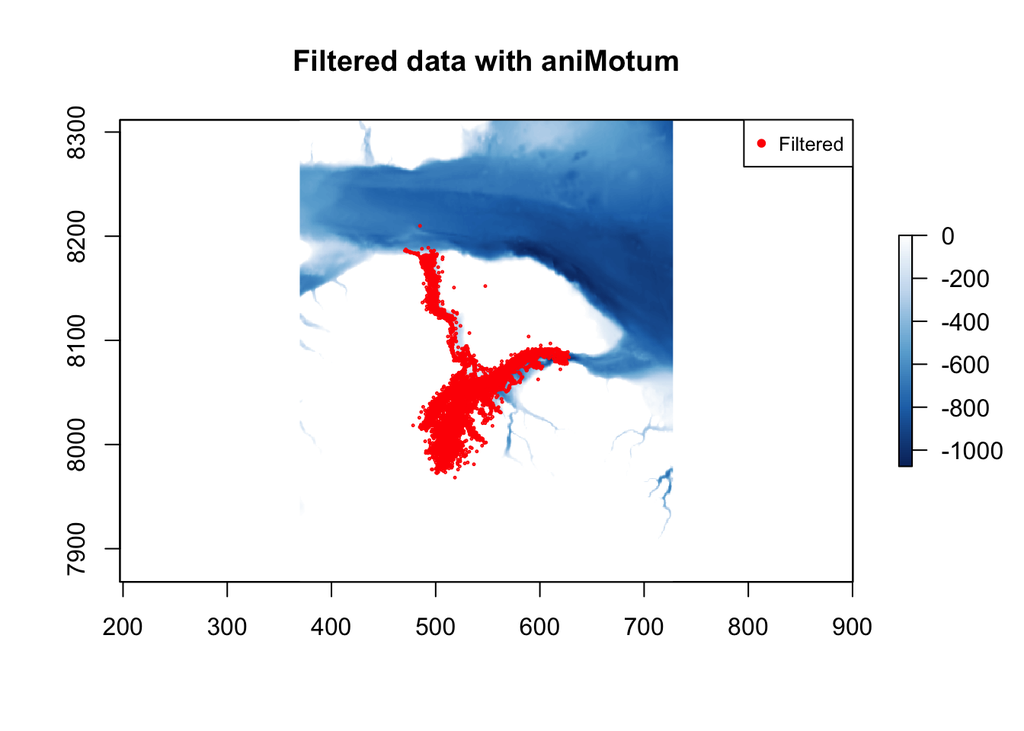

```r
plot(
  bathy,
  col  = colorRampPalette(c("#08306b", "#2171b5", "#6baed6", "#c6dbef", "white"))(100),
  main = "Filtered data with aniMotum"
)

points(data_ALLfiltered.sf$X, data_ALLfiltered.sf$Y, cex = 0.2, col = "red")  # filtered data

legend(
  "topright",
  legend = c("Filtered"),
  col = c("red"),
  pch = 16,
  cex = 0.8
)
```

## (b) Prep the covariates

```r
# Put environmental covariates into a list
covList <- list(terra::rast(bathy_scaled))
names(covList) <- "bathy"
# Note: no landmask is included for the two-step method
```

## (c) Prep model parameters

```r
# Parameters of the model to fit
model <- "underdamped"

## smooth gradient specifications (based on adjacent cells)
## slows model fitting, but can reduce bias if \Delta_t is large (i.e. samplingRate > 1) relative to timeStep (Blackwell & Matthiopoulos 2024, https://doi.org/10.1002/ecy.4457)

npoints <- 0 # number of smoothing points around current raster cell (0 = none, 4 = diagonal, 8 = queen neighborhood)
curweight <- 1/2 # weight of the current cell in smoothing
weights <- c(curweight, rep((1-curweight)/npoints, npoints)) # smoothing weights
zetaScale <- 1  # scaling factor for smooth gradient neighborhood


# Initialise data list for TMB
dat <- data.frame(
  x = data_ALLfiltered.sf$X,
  y = data_ALLfiltered.sf$Y
)
dat$time <- data_ALLfiltered.sf$date
dat$id <- as.numeric(as.integer(factor(data_ALLfiltered.sf$id)))
# langevinSSM::fitLangevin fits the model with no measurement error when all smaj=NA, smin=NA, eor=NA, x.sd=NA, and y.sd=NA
dat$smaj <- rep(NA,length(dat$time))
dat$smin <- rep(NA,length(dat$time))
dat$eor <- rep(NA,length(dat$time))
dat$x.sd<- rep(NA,length(dat$time))
dat$y.sd <- rep(NA,length(dat$time))
dat$lc <- rep(NA,length(dat$time))

dat <- langevinSSM::formatData(dat,
  id = "id",
  date = "time",
  coord = c("x", "y"),
  epar = c("smaj", "smin", "eor"))


# Location values
init.mu <- cbind(dat$x,dat$y) # filtered locations  (mu is not estimated here)
```

In particular, for the two-step approach, the data have already been corrected:

- There are **no missing observations**.
- There is **no specification of measurement error ellipses**, because we assume the filtered locations are accurate (hence the NAs in the code)

All observed positions are treated as correct inputs to the model, and the subsequent analysis focuses on fitting the Langevin movement model and including environmental covariates.

The model is then fitted using `fitLangevin()`, and we use the following arguments:

- `data`: a formatted dataset in `formatData` format
- `spatial.covs`: the spatial covariates (raster layers) used to define the RSF

By default, `fitLangevin()` first performs an inner optimization over the random effects (here `vel`) before optimizing over all parameters (`inner.optimizer = TRUE`), which improves numerical stability and convergence.

## (c) Fit the Langevin model to the filtered data.

```r
Nrep <- 30                                       # number of random initializations to explore
nllkALL_filtered <- array()                       # store negative log-likelihoods for each fit
parMat <- matrix(NA, nrow = Nrep, 3)      # store estimated parameters
NarwhalALL_filtered <- rep <- list()              # list to store model fits and reports
colnames(parMat) <- c(paste0("beta",1), "sigma","gamma")  # parameter names

# Fit the Langevin model to the filtered narwhal data



for (irep in 1:Nrep) {
  if(irep==1){
    # Neutral initialization
    parm <- langevinSSM::initialValues(dat,spatialCovs = covList) # 'parm' includes neutral starting values from langevinSSM::initialValues, v_mu

  }else{
  # Initialize movement and selection parameter values randomly
  sigma <- abs(rnorm(1, 0, 3))   # speed parameter
  gamma <- abs(rnorm(1, 0, 3))   # friction parameter (directional persistence)
  beta  <- c(rnorm(1, 0, 3))     # resource selection coefficient
  psi <- 1                       # SD scaling of observation error (not used here)

  # Initialize latent velocity (vel) for underdamped Langevin
  init.v_mu <- matrix(0, length(dat$id),2)
  for (i in 1:nbAnimals) {
      aInd <- which(data_ALLfiltered.sf$id == unique(data_ALLfiltered.sf$id)[i])
      # approximate initial velocities as finite differences, adjusted by gamma
      init.v_mu[aInd[-1],1] <- diff(init.mu[aInd,1]) /
        (data_ALLfiltered.sf$dt[aInd[-1]] * exp(-gamma * data_ALLfiltered.sf$dt[aInd[-1]]))
      init.v_mu[aInd[-1],1] <- diff(init.mu[aInd,1]) /
        (data_ALLfiltered.sf$dt[aInd[-1]] * exp(-gamma * data_ALLfiltered.sf$dt[aInd[-1]]))
  }
   # Prepare the list of parameters for TMB
    parm <- list(
      sigma = sigma,
      beta = beta,
      vel = init.v_mu,
      gamma = gamma)

  }
    # Fit with the fixed selection parameters initialized at their true values and velocity derived from location
    NarwhalALL_filtered[[irep]] <- fitLangevin(dat,par=parm,spatialCovs=covList,
                                 silent=TRUE, control=list(trace=0))


    # Store parameter estimates
    parMat[irep, 1:3] <- NarwhalALL_filtered[[irep]]$par
    parMat[irep, "sigma"] <- NarwhalALL_filtered[[irep]]$estimates$natural["sigma",1]
    if (model == 1) parMat[irep, "gamma"] <- NarwhalALL_filtered[[irep]]$estimates$natural["gamma",1]

    # Record negative log-likelihood if fit converged
    if (NarwhalALL_filtered[[irep]]$convergence != 0) {
      nllkALL_filtered[irep] <- NA
    } else {
      if (sum(is.na(NarwhalALL_filtered[[irep]]$sdreport[,2])) == 0) {
        nllkALL_filtered[irep] <- NarwhalALL_filtered[[irep]]$objective
      } else {
        nllkALL_filtered[irep] <- NA
      }
    }
}
```

[output not shown]

```r
idx <- which.min(nllkALL_filtered)                 # Find the replicate with the lowest negative log-likelihood

# estUD_2step <- langevinSSM::getUD(spatialCovs = covList, fit = NarwhalALL_filtered[[idx]])
mask_terra <- mask
# estUD_2step[mask_terra == 1] <- NA
# plot(estUD_2step)

# This should be the same as below
estUD_2step <-  NarwhalALL_filtered[[idx]]$par[1]*covList$bathy
estUD_2step[mask_terra == 1] <- NA # UD is not defined on land

# plot(estUD_2step)
```

```r
# Get 95% confidence intervals for selection parameters
lower <-  NarwhalALL_filtered[[idx]]$estimates$natural[1,1] - qnorm(0.975) *  NarwhalALL_filtered[[idx]]$estimates$natural[1,2]
upper <-  NarwhalALL_filtered[[idx]]$estimates$natural[1,1]+ qnorm(0.975) * NarwhalALL_filtered[[idx]]$estimates$natural[1,2]

ci_ALL <- data.frame(
  Coeff = c("bathy"),
  Estimate = NarwhalALL_filtered[[idx]]$estimates$natural[1,1],
  StdError = NarwhalALL_filtered[[idx]]$estimates$natural[1,2],
  CI_Lower = lower,
  CI_Upper = upper,
  Type = "ALL_filtered"
)
```

```r
extracted <- terra::extract(mask, vect(data_ALL.sf))[, 2]
onLand <- extracted == 1              # TRUE/FALSE/NA per point


#  Estimated locations from 2step
df <- data.frame(
  X = init.mu[, 1],
  Y = init.mu[, 2]
)
res_2step_spdf_False.sf <- st_as_sf(df, coords = c("X", "Y"), remove = FALSE, crs = crs(bathy))
pts_est <- vect(res_2step_spdf_False.sf)

onLand.res_2step_spdf_False.sf <- as.logical(terra::extract(mask, pts_est)[, 2])
```

```r
# Number of locations that are on land (raw data)
n_raw_land <- sum(onLand)

# How many of them are on water now (after model fitting)
n_raw_land_now_water <- sum(onLand & !onLand.res_2step_spdf_False.sf)

# How many that were on water are pushed on land by aniMotum
n_raw_water_now_land <- sum((!onLand) & onLand.res_2step_spdf_False.sf)
```

# 3. Fit a Langevin SSM, estimate the observation error scaling ($\psi$)

In this section, we fit the SSM with $\psi$ treated as a free parameter to account for potential inaccuracies in the location uncertainties, such as systematic underestimation from the Kalman filter and the circular error assumption in the measurement error. We include **two covariates**: bathymetry and a landmask^2.

The landmask acts as a **spatial constraint**, ensuring that estimated locations falling on land are penalized and thus pushed toward water. As noted earlier, this langevin SSM is implemented using custom code, as it incorporates penalties on $\sigma$, $\psi$, and the landmask, which are not currently available in the package.

## (a) Prep covariates

```r
# Same as becore but with two covariates
# Put cov in a list
covList <- list(bathy_scaled,landmask2_scaled)
names(covList) <- c("bathy","landmask2")
# Stack them into a multi-layer SpatRaster
raster_stack <- stack(covList)


raster_data <- list(
  raster_vals = array(as.numeric(values(raster_stack)),
                      dim = c(nlayers(raster_stack),
                              nrow(raster_stack),
                              ncol(raster_stack))),
  raster_coords = coordinates(raster_stack),
  raster_resolution = res(raster_stack),
  raster_extent = c(xmin(raster_stack), xmax(raster_stack),
                    ymin(raster_stack), ymax(raster_stack)),
  n_covs = nlayers(raster_stack)
)
```

We add a **mask covariate**, which corresponds to $p_1$ in equation (16) of the paper.

```r
maskList <- list(landmask_scaled)
names(mask) <- c("landmask")
# Stack them into a multi-layer SpatRaster
raster_stack <- stack(maskList)


# Following the simulation.R code
mask_data <- list(
  mask_vals = array(as.numeric(values(raster_stack)),
                      dim = c(nlayers(raster_stack),
                              nrow(raster_stack),
                              ncol(raster_stack))),
  mask_coords = coordinates(raster_stack),
  mask_resolution = res(raster_stack),
  mask_extent = c(xmin(raster_stack), xmax(raster_stack),
                      ymin(raster_stack), ymax(raster_stack))
)
```

## (b) Prep data and model parameters

```r
data <- data_ALL

# same as before but put them again for the sake of ...
model <- 1 # underdamped Langevin model (1 = underdamped, 0 = overdamped)
tracepar <- FALSE    # if TRUE, trace parameters during optimization iterations


## smooth gradient specifications (based on adjacent cells)
## slows model fitting, but can reduce bias if \Delta_t is large (i.e. samplingRate > 1) relative to timeStep (Blackwell & Matthiopoulos 2024, https://doi.org/10.1002/ecy.4457)

npoints <- 0 # number of smoothing points around current raster cell (0 = none, 4 = diagonal, 8 = queen neighborhood)
curweight <- 1/2 # weight of the current cell in smoothing
weights <- c(curweight, rep((1-curweight)/npoints, npoints)) # smoothing weights
zetaScale <- 1  # scaling factor for smooth gradient neighborhood

# Round timestamps to nearest second for consistency
data$datetime_UTC_round <- floor_date(data$datetime_UTC, "second")
data_ALLfiltered.sf$date_round <- floor_date(data_ALLfiltered.sf$date, "second")
# Compute time differences between consecutive points for each animal
data_ALLfiltered.sf <- data_ALLfiltered.sf %>%
  arrange(id, date_round) %>%
  group_by(id) %>%
  mutate(
    time1_round = lag(date_round),                            # previous timestamp
    dt_round = as.numeric(difftime(date_round, time1_round, units = "hours"))  # delta time in hours
  ) %>%
  ungroup()

# Replace NA time differences (i.e., first observation) with 0
data_ALLfiltered.sf$dt_round[which(is.na(data_ALLfiltered.sf$dt_round))] <- 0


# Combine filtered locations with original data for measurement error info
data_aniMotum <- data_ALLfiltered.sf %>%
  left_join(
    data %>%
      dplyr::select(ID, datetime_UTC_round, X, Y, smaj, smin, eor,loc_class) %>%
      rename(X.raw = X, Y.raw = Y),  # keep raw coordinates for SSM fitting
    by = c("id" = "ID", "date_round" = "datetime_UTC_round")
  )


# Prepare data list for TMB model
dat <- list(
  model = model,
  Y = as.matrix(rbind(data_aniMotum$X.raw, data_aniMotum$Y.raw)), # observed locations
  dt = data_aniMotum$dt_round,                                 # time differences
  lc = data_aniMotum$loc_class
)
dat$isd <- rep(1, length(data_aniMotum$id))                   # indicate all points are observed
dat$obs_mod <- rep(NA, ncol(dat$Y))                           # placeholder for observation model
dat$obs_mod[dat$isd == 1] <- 1                                # mark observed points
dat$ID <- as.numeric(as.integer(factor(data_aniMotum$id)))    # numeric animal IDs
dat$nbStates <- 1                                             # only one hidden state for HMM Langevin (as with two-step method)
dat$nbObs <- rep(1, ncol(dat$Y))                              # number of observations per time step
dat$smaj <- data_aniMotum$smaj                                # semi-major axis of measurement error ellipse
dat$smin <- data_aniMotum$smin                                # semi-minor axis
dat$eor <- data_aniMotum$eor                                  # orientation of ellipse
dat$obs_mod[dat$lc == "G"] <- 0                                 # LS for all GPS
dat$K <- matrix(NA, ncol(dat$Y), 2)                           # placeholder for future use
dat$K[dat$lc == "G",] <- rep(50,2)/1000                # GPS has an LS model with 50m x.err = y.err
# dat$smaj[dat$lc == "G"] <- NA                                 # LS for all
# dat$smin[dat$lc == "G"] <- NA                                # LS for all
# dat$eor[dat$lc == "G"] <- NA                                 # LS for all

dat$scale_factor <- 1
dat <- c(dat, raster_data, mask_data)                         # include covariates and mask
dat$smoothGradient <- ifelse(npoints > 0, 1, 0)               # indicate if smoothing is applied
dat$weights <- weights
dat$zetaScale <- zetaScale

# Initial latent locations: start at the observed (raw) locations
init.mu <- as.matrix(rbind(data_aniMotum$X.raw, data_aniMotum$Y.raw))
dat$lc <- NULL                                             # drop lc now that it's no longer needed
```

As in the previous model, there are no missing observations because we predict at the times of the recorded locations. However, unlike before, this model accounts for measurement error through the estimated error ellipses and estimates $\psi$ parameter, which scales the semi-minor axis of the ARGOS / GPS error ellipse.

Since the `langevinSSM` package does not yet support penalties, the Langevin SSM is implemented directly in TMB using the `fitLangevin_maskpen_neg.cpp` file, which encodes the three penalties $p_1$, $p_2$, and $p_3$ and constrains the coefficient associated with the landmask squared covariate to be negative. Specifically, `fitLangevin_maskpen_neg` adds a negative coefficient associated with the last covariate provided (here, `landmask2`). This covariate is not intended for resource selection, but rather to implement a spatial constraint that discourages predicted locations from being on land within the Langevin model.

## (c) Fit Langevin SSM with land-mask penalty

```r
# Fit Langevin SSM with land-mask penalty

# Compile/load TMB model
compile("src/fitLangevin_maskpen_neg.cpp")
dyn.load(dynlib("src/fitLangevin_maskpen_neg"))

# Setup for multiple initializations
Nrep <- 30                    # number of random initial values to explore
nllk <- array()               # store negative log-likelihoods
parMat <- matrix(NA, nrow=Nrep+1, 7) # store estimated parameters
NarwhalALL <- rep <- list()   # store fitted objects and reports
colnames(parMat) <- c( paste0("beta",1:2), "sigma","gamma", "psi","l_tau","l_tau") # one more beta than two-step, associated with land_mask


# Loop over initializations
for (irep in 1:Nrep){
  if(irep ==1){
    beta = c(0,-1e4) # bc the second coefficient is on log scale
    dat_notformat <- data.frame(
                      model = model,
                      x = data_aniMotum$X.raw,
                      y = data_aniMotum$Y.raw,
                      date = data_aniMotum$date)

    dat_notformat$id <-  dat$ID

    dat_format <- langevinSSM::formatData(dat_notformat,
    id = "id",
    date = "date",
    coord = c("x", "y"))

    parm_langevinSSM <- initialValues(dat_format,spatialCovs=covList)
    parm <- list(
      log_sigma = log(parm_langevinSSM$sigma),
      beta = matrix(beta,1,length(beta)),
      mu = init.mu,           # initial locations
      vel =   init.v_mu <- matrix(0, 2, ncol(dat$Y)),
      log_gamma = log(parm_langevinSSM$gamma),
      l_delta = 0,
      l_gamma = matrix(0,1,2),
      l_psi = 0,
      l_tau = c(0,0),
      l_rho_o = 0
    )

  }else{
  sigma <- abs(rnorm(1,0,3))       # movement scale
  gamma <- abs(rnorm(1,0,3))       # friction/velocity persistence
  beta <- c(rnorm(2,0,3))          # resource selection coefficients
  psi <- 1                         # measurement error SD scaling
  tau = c(1,1)
  init.mu <- as.matrix(rbind(data_aniMotum$X.raw, data_aniMotum$Y.raw))
  # Compute initial velocities for each animal
  init.v_mu <- matrix(0, 2, ncol(dat$Y))
  for(i in 1:nbAnimals){
    aInd <- which(data_aniMotum$id == unique(data_aniMotum$id)[i])
    init.v_mu[1,aInd[-1]] <- diff(init.mu[1,aInd]) /
      (data_aniMotum$dt[aInd[-1]] * exp(-gamma * data_aniMotum$dt[aInd[-1]]))
    init.v_mu[2,aInd[-1]] <- diff(init.mu[2,aInd]) /
      (data_aniMotum$dt[aInd[-1]] * exp(-gamma * data_aniMotum$dt[aInd[-1]]))
  }


    # Parameter list for TMB
    parm <- list(
      log_sigma = log(sigma),
      beta = matrix(beta,1,length(beta)),
      mu = init.mu,           # initial locations
      vel = init.v_mu,       # initial velocities
      log_gamma = log(gamma),
      l_delta = 0,
      l_gamma = matrix(0,1,2),
      l_psi = log(psi),
      l_tau = log(tau),
      l_rho_o = 0
    )
  }

    re <- c("mu", "vel")        # treat locations and velocities as random effects
    map_inner <- lapply(parm[names(parm)[!names(parm) %in% c("mu","vel")]], function(x) factor(rep(NA,length(x))))

    obj1 <- TMB::MakeADFun(
        dat,
        parm,
        map = map_inner,
        random = re,
        DLL = "fitLangevin_maskpen_neg",
        hessian = TRUE,
        silent = TRUE,
        inner.control = list(maxit = 10000, trace=0)
      )

   # obj1$fn()

    smoothed_pars <- obj1$env$parList()

    parm$mu <- smoothed_pars$mu
    parm$vel <- smoothed_pars$vel

   map <- list(
    l_delta  = factor(NA),
    l_gamma  = factor(c(NA, NA)),
    l_rho_o  = factor(NA))

  # Create AD function for TMB
  # message("   Fitting model...")
  obj2 <- MakeADFun(
    dat,
    parm,
    map = map,
    random = re,
    DLL = "fitLangevin_maskpen_neg",
    hessian = TRUE,
    silent = TRUE,
    inner.control = list(maxit = 10000, trace=0)
  )

  obj2$env$tracepar <- tracepar

  # Optimize
  NarwhalALL[[irep+1]] <- tryCatch(
    {
      do.call("nlminb",
              args = list(
                start = obj2$par,
                objective = obj2$fn,
                gradient = obj2$gr,
                control = list(trace = 10, iter.max = 10000, eval.max = 10000)
              )
      )
    },
    error = function(e){
      message("Error in iteration ", irep, ": ", e$message)
      return(NA)
    },
    warning = function(w){
      message("Warning in iteration ", irep, ": ", w$message)
      return(NA)
    }
  )

  # Calculate SEs and store results if optimization converged

  if(sum(is.na(NarwhalALL[[irep+1]])) == 0){
    # message("   Calculating SEs...")
    rep[[irep+1]] <- obj2$report()
    sdrep <- sdreport(obj2)
    NarwhalALL[[irep+1]]$sdreport <- summary(sdrep,"report")

    # Store estimated parameters
    parMat[irep+1, 1:2] <- NarwhalALL[[irep+1]]$par[2:3]
    parMat[irep+1, 6:7] <- NarwhalALL[[irep+1]]$par[6:7]
    parMat[irep+1, "sigma"] <- rep[[irep+1]]$sigma
    if(model == 1) parMat[irep+1, "gamma"] <- rep[[irep+1]]$gamma
    if(model == 1) parMat[irep+1, "psi"] <- rep[[irep+1]]$psi
    # Store negative log-likelihood
    if(NarwhalALL[[irep+1]]$convergence != 0){
      nllk[irep+1] <- NA
    } else {
      if(sum(is.na(NarwhalALL[[irep+1]]$sdreport[,2]))==0){
        nllk[irep+1] <- NarwhalALL[[irep+1]]$objective
      } else {
        nllk[irep+1] <- NA
      }
    }
  } else {
    nllk[irep+1] <- NA
  }
}

# Unload TMB dynamic library

dyn.unload(dynlib("src/fitLangevin_maskpen_neg"))
```

```r
thresh <- quantile(values(estUD_final), 0.90, na.rm = TRUE)

top10_yesno <- estUD_final >= thresh
top10_loc <- which(values(top10_yesno) == 1)
depth_vals  <- values(bathy)[top10_loc]
range(depth_vals)
```

```
## [1] -1075.6960  -904.7858
```

Let us look at the estimated coefficients:

```r
ALLpar_final
```

```
## log_sigma      beta      beta log_gamma     l_psi     l_tau     l_tau
##  1.641937 -4.239923  4.675386  2.393614  1.626630  1.361410  1.417100
```

```r
# exp(ALLpar_final[1])

cat("This corresponds to an average movement speed of", sqrt(pi/2)*exp(ALLpar_final[1]), "and a persistence time scale of", 3/exp(ALLpar_final[4])*60, "minutes.")
```

```
## This corresponds to an average movement speed of 6.473575 and a persistence time scale of 16.43384 minutes.
```

Note that $\beta_2$ is not transformed, in the code it is $-exp(\beta_2)$ associated with the land, and so it should be transformed as such to be interpreted.

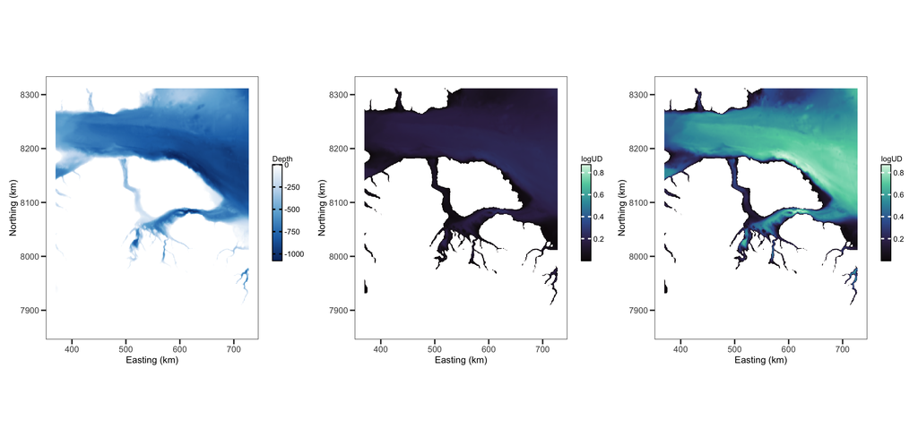

```r
# convert to data frames
df1 <- as.data.frame(estUD_final, xy = TRUE, na.rm = FALSE)
df2 <- as.data.frame(estUD_2step, xy = TRUE, na.rm = FALSE)
names(df1)[3] <- "logUD"
names(df2)[3] <- "logUD"
zlim <- range(c(df1$logUD, df2$logUD), na.rm = TRUE)

shared_theme <- theme_bw() +
  theme(panel.grid         = element_blank(),
        plot.title         = element_text(hjust = 0.5, size = 11),
        legend.text        = element_text(size = 9, margin = margin(l = 3)),
        legend.title       = element_text(size = 9, margin = margin(b = 3)),
        axis.text          = element_text(size = 10),
        axis.title         = element_text(size = 11),
        axis.ticks         = element_line(linewidth = 0.8),
        axis.ticks.length  = unit(0.2, "cm"))

ud_guide <- guides(fill = guide_colorbar(
  barwidth        = unit(0.4, "cm"),
  barheight       = unit(4,   "cm"),
  ticks.linewidth = 0.8,
  ticks.colour    = "white",
  frame.colour    = "black",
  frame.linewidth = 0.5
))

p1 <- ggplot(df1, aes(x = x, y = y, fill = logUD)) +
  geom_raster() +
  scale_fill_viridis_c(option = "mako", limits = zlim, na.value = "white") +
  coord_equal() +
  ud_guide +
  labs(title = "", x = "Easting (km)", y = "Northing (km)") +
  shared_theme

p2 <- ggplot(df2, aes(x = x, y = y, fill = logUD)) +
  geom_raster() +
  scale_fill_viridis_c(option = "mako", limits = zlim, na.value = "white") +
  coord_equal() +
  ud_guide +
  labs(title = "", x = "Easting (km)", y = "Northing (km)") +
  shared_theme

p3 <- ggplot(df_bathy, aes(x = x, y = y, fill = depth)) +
  geom_raster() +
  scale_fill_gradientn(
    colours  = colorRampPalette(c("#08306b", "#2171b5", "#6baed6", "#c6dbef", "white"))(100),
    na.value = "white"
  ) +
  guides(fill = guide_colorbar(
    barwidth        = unit(0.4, "cm"),
    barheight       = unit(4,   "cm"),
    ticks.linewidth = 0.8,
    ticks.colour    = "black",
    frame.colour    = "black",
    frame.linewidth = 0.5
  )) +
  labs(title = "", x = "Easting (km)", y = "Northing (km)", fill = "Depth") +
  shared_theme

combined_plot <- p3 | p2 | p1
combined_plot
```

```r
ggsave("plots/bathy_UD_panels.pdf", combined_plot, width = 15, height = 7, units = "in")
```

```r
# Get 95\% CI
lower <- NarwhalALL[[idx]]$sdreport[,1] - qnorm(0.975) * NarwhalALL[[idx]]$sdreport[,2]
upper <- NarwhalALL[[idx]]$sdreport[,1] + qnorm(0.975) * NarwhalALL[[idx]]$sdreport[,2]

ci_neg <- data.frame(
  Coeff = c("bathy"),
  Estimate = NarwhalALL[[idx]]$sdreport[1,1],
  StdError = NarwhalALL[[idx]]$sdreport[1,2],
  CI_Lower = lower[1],
  CI_Upper = upper[1],
  Type = "ALL_SSM_spdf_False"
)
ci = rbind(ci_neg,ci_ALL)

ci
```

```
##            Coeff  Estimate  StdError  CI_Lower   CI_Upper               Type
## beta_trans bathy -4.239923 0.6514294 -5.516701 -2.9631450 ALL_SSM_spdf_False
## 1          bathy -1.289230 0.2849655 -1.847752 -0.7307082       ALL_filtered
```

```r
# Extract the SSM fit corresponding to the best replicate
rep_neg <- rep[[idx]]
rep_final <- rep_neg

# Create a data frame of estimated SSM locations (mu) from the fit
df <- data.frame(
  X = rep_final$mu[1,],
  Y = rep_final$mu[2,]
)

# Convert estimated SSM locations to sf object
res_ssm_spdf_false.sf <- st_as_sf(df, coords = c("X", "Y"), remove = FALSE, crs = crs(bathy))

pts_est <- vect(res_ssm_spdf_false.sf)

onLand.res_ssm_spdf_false.sf <- as.logical(terra::extract(mask, pts_est)[, 2])
```

```r
 pdf("plots/pushed_loc_onlybathy.pdf",
   width = 35,
   height = 40)
estUD <- (ALLpar_final[3] * covList$bathy)
estUD[raster(mask) == 1] <- NA

plot(
  estUD,
  col = viridis::mako(100),
  legend = FALSE,
  axes = FALSE,
  box = FALSE,
  main = "",
  xlab = "",
  ylab = ""
)

# raw locations
points(
  dat$Y[1, idx_raw_land_now_water_SSM],
  dat$Y[2, idx_raw_land_now_water_SSM],
  pch = 21,
  bg = "#D55E00",
  col = "black",
  cex = 5 # cex 5 for manuscript
)

points(
  rep_final$mu[1, idx_raw_land_now_water_SSM],
  rep_final$mu[2, idx_raw_land_now_water_SSM],
  pch = 21,
  bg  = "#009E73",
  col = "black",
  cex = 5 # cex 5 for manuscript
)
title(
  "(a) Locations remaining on land (raw in orange, estimated in green) with associated uncertainty ellipses",
  cex.main = 3,      # font size multiplier
  font.main = 1,     # 1 = plain, 2 = bold, 3 = italic
  col.main = "black" # title color
)
 dev.off()
```

```r
ud_df <- as.data.frame(estUD, xy = TRUE, na.rm = FALSE)
names(ud_df) <- c("x", "y", "ud")


ellipse_df <- data.frame(
  x0    = dat$Y[1, idx_pushed_onLand],
  y0    = dat$Y[2, idx_pushed_onLand],
  a     = ani_data$smaj[idx_pushed_onLand],
  b     = ani_data$smin[idx_pushed_onLand],
  angle = ani_data$eor[idx_pushed_onLand]*pi/180  # should already be radians
)

mu_df <- data.frame(
  x = rep_final$mu[1, idx_pushed_onLand],
  y = rep_final$mu[2, idx_pushed_onLand]
)

# (b) Locations originally on water that were pushed onto land

 pdf("plots/pushed_land_loc_onlybathy.pdf", width = 35, height = 40)

p <- ggplot() +
  geom_raster(data = ud_df, aes(x = x, y = y, fill = ud)) +
  scale_fill_viridis_c(option = "mako", na.value = NA, guide = "none") +
  geom_point(
    data = ellipse_df,
    aes(x = x0, y = y0),
    shape = 21,
    fill = "#D55E00",
    colour = "black",
    size = 10
  ) +
  geom_point(
    data = mu_df,
    aes(x = x, y = y),
    shape = 21,
    fill = "#009E73",
    colour = "black",
    size = 10,
    stroke = 1.2
  ) +
  coord_equal() +
  theme_void() +
  #labs(title = "(b) Locations originally on water (orange) pushed onto land (green)") +
  theme(
    plot.title = element_text(size = 30, face = "plain", colour = "black")
  )
 print(p)
dev.off()
```

```r
# (c) Locations originally on land that were pushed onto water
pdf("plots/stay_on_land_loc_onlybathy.pdf", width = 35, height = 40)

p <- ggplot() +
  geom_raster(data = ud_df, aes(x = x, y = y, fill = ud)) +
  scale_fill_viridis_c(option = "mako", na.value = NA, guide = "none") +
  geom_point(
    data = ellipse_df,
    aes(x = x0, y = y0),
    shape = 21,
    fill = "#D55E00",
    colour = "black",
    size = 10
  ) +
    geom_ellipse(
    data = ellipse_df,
    aes(x0 = x0, y0 = y0, a = a, b = b, angle = angle),
    fill = "#D55E00",
    alpha = 0.25,
    colour = "#B24700",
    linewidth = 0.6
  ) +
  geom_point(
    data = mu_df,
    aes(x = x, y = y),
    shape = 21,
    fill = "#009E73",
    colour = "black",
    size = 10, # size 10 for the manuscript.
    stroke = 1.2
  ) +
  coord_equal() +
  theme_void() +
  labs(title = "(c) Locations originally on land (orange) pushed onto water (green)") +
  theme(
    plot.title = element_text(size = 30, face = "plain", colour = "black")
  )
print(p)
 dev.off()
```

```
## Total raw location on land 3722
```

| Method | Locations pushed to water | Locations pushed to land | Total number of location on land |
| --- | --- | --- | --- |
| SSM (spdf = FALSE) | 2825 | 191 | 1088 |
| Two-step (spdf = FALSE) | 3066 | 3065 | 3721 |